# Supplemental Online Material – R script for ‘Causal Mediation Analysis for Psychological Research: Insights From the Forward Testing Effect Study’

# Initial Setup

## Analysis setup

Data from the Forward Testing Effect (hereafter FTE) study can be accessed at an anonymized repository at: https://osf.io/jyrq8/?view_only=ede69ce309484a40bc50904358e7abb7.

Most of the data setup follows `FTE14a__mother_script.Rmd` found in the original repository.

```r
# 1. Set paths to specific folders in the working directory
data.path <- "data/"

# 2. Load packages
packages <- c("knitr", "tidyverse", "psych", "ggplot2", "rstatix", "doParallel", "car",
              "kableExtra", "mediation")

# automatically tries to retrieve packages that are not yet installed.
package.check <- lapply(packages, function(x) {
  if (!require(x, character.only = TRUE)) {
    install.packages(x, dependencies = TRUE)
    library(x, character.only = TRUE)
  }
})

# 3. Load data
df <- read.csv2(file.path(data.path, "fet14a_data_osf.csv"))

# 4. Some general settings that can be kept constant
# general behavior of chunk (outputs)
knitr::opts_chunk$set(
  warning = F, # suppress warnings and
  message = F  # messages
  )

# kable output
options(knitr.kable.NA = '')

# settings to run analyses on multiple cores
no.cores = parallel::detectCores() - 4  # 8
cl = makeCluster(rep("localhost", no.cores))  # run all workers on local machine, 8 times
```

## Data preparations

`practice_type` is treated as a factor and change in cognitive effort is calculated as the difference score between `cognitive.effort_text1` and `cognitive.effort_text3`. `practice_type_bi` is a dummy variable with Restudy = 0, Retrieval = 1.

```r
# Create factor and DeltaCE (cognitive.effort_diff)
df <- df %>%
  mutate(
    practice_type = factor(practice_type, levels = c("Restudy", "Retrieval")),
    cognitive.effort_diff = cognitive.effort_text1 - cognitive.effort_text3)

# Data cleaning to create dummy variable for practice type
df <- df %>%
  mutate(practice_type_bi = ifelse(practice_type == "Restudy", 0, 1))

# Create gender dummy variables for descriptive statistics and mediation analysis
df$male <- ifelse(df$gender == "male", 1, 0)
df$diverse <- ifelse(df$gender == "diverse", 1, 0)
```

## Data exclusion

Participants were excluded following the original FTE study if participants reported

- high disturbance (> 7) and low concentration (< 4) ($n = 8$),
- use of external help (e.g., taking notes) ($n = 8$),
- same study participation ($n = 4$), or
- language other than German ($n = 13$).

In total, data from 33 subjects were excluded from our analysis.

```r
# Filter a subset of subjects based on exclusion criteria
Excl <- df %>%
  mutate(
    Excl_dist = disturbed > 7 & concentration < 4,
    Excl_help = external.help == "yes",
    Excl_same.study = participated.before == "I have participated at the SAME study before.",
    Excl_language = language == "other") %>%

  filter(Excl_dist == T |
           Excl_help == T |
           Excl_same.study == T |
           Excl_language == T)

# Apply exclusion criteria
df <- df %>%
  filter(!(ID %in% Excl$ID))  # 308 -> 275
```

## Descriptive statistics (Table 1)

Below are descriptive statistics of variables used in further analyses (presented as Table 1 in the manuscript).

```r
# Overall sample
library(psych)
describe(df[, c("practice_type_bi", "cognitive.effort_diff",
                "cognitive.effort_text1", "cognitive.effort_text3",
                "test.final_text3_sum", "interest_text1",
                "prior.knowledge_text1", "episodic.memory_acc",
                "sellmo_learninggoals", "male", "diverse",
                "age")])[, c(2:5, 8:9, 11:12)]
```

```
##                          n  mean    sd median min max  skew kurtosis
## practice_type_bi       275  0.47  0.50    0.0   0   1  0.11    -2.00
## cognitive.effort_diff  275  0.42  1.65    0.0  -7   8  0.22     3.75
## cognitive.effort_text1 275  6.19  1.93    6.0   1   9 -0.59    -0.23
## cognitive.effort_text3 275  5.77  2.13    6.0   1   9 -0.41    -0.57
## test.final_text3_sum   275  8.74  3.77    9.0   0  16 -0.34    -0.68
## interest_text1         275  5.48  2.33    6.0   0   9 -0.43    -0.53
## prior.knowledge_text1  275 42.19 28.91   40.0   0 100  0.13    -1.08
## episodic.memory_acc    275  0.62  0.23    0.6   0   1 -0.37    -0.36
## sellmo_learninggoals   275 48.99  7.01   51.0   8  56 -2.48     8.79
## male                   275  0.24  0.43    0.0   0   1  1.21    -0.54
## diverse                275  0.01  0.09    0.0   0   1 11.53   131.52
## age                    275 31.07 10.19   29.0  18  77  1.22     1.46
```

```r
# Descriptive statistics by practice type
describeBy(df[, c("cognitive.effort_diff", "cognitive.effort_text1",
                  "cognitive.effort_text3", "test.final_text3_sum",
                  "interest_text1", "prior.knowledge_text1",
                  "episodic.memory_acc", "sellmo_learninggoals", "male",
                  "diverse", "age")], df$practice_type)
```

```
##
##  Descriptive statistics by group
## group: Restudy
##                        vars   n  mean    sd median trimmed   mad   min max
## cognitive.effort_diff     1 145  0.61  1.56    0.0    0.55  1.48 -4.00   8
## cognitive.effort_text1    2 145  6.17  1.99    7.0    6.30  1.48  1.00   9
## cognitive.effort_text3    3 145  5.55  2.27    6.0    5.64  2.97  1.00   9
## test.final_text3_sum      4 145  8.11  3.84    8.0    8.24  4.45  0.00  16
## interest_text1            5 145  5.48  2.30    6.0    5.62  2.97  0.00   9
## prior.knowledge_text1     6 145 42.86 29.53   44.0   42.38 37.06  0.00 100
## episodic.memory_acc       7 145  0.62  0.22    0.6    0.63  0.20  0.07   1
## sellmo_learninggoals      8 145 48.54  8.01   51.0   49.99  4.45  8.00  56
## male                      9 145  0.26  0.44    0.0    0.20  0.00  0.00   1
## diverse                  10 145  0.01  0.12    0.0    0.00  0.00  0.00   1
## age                      11 145 30.86 10.88   27.0   29.18  8.90 18.00  77
##                         range  skew kurtosis   se
## cognitive.effort_diff   12.00  0.69     2.94 0.13
## cognitive.effort_text1   8.00 -0.55    -0.43 0.17
## cognitive.effort_text3   8.00 -0.31    -0.99 0.19
## test.final_text3_sum    16.00 -0.23    -0.91 0.32
## interest_text1           9.00 -0.49    -0.43 0.19
## prior.knowledge_text1  100.00  0.05    -1.22 2.45
## episodic.memory_acc      0.93 -0.20    -0.51 0.02
## sellmo_learninggoals    48.00 -2.63     8.32 0.66
## male                     1.00  1.11    -0.77 0.04
## diverse                  1.00  8.25    66.54 0.01
## age                     59.00  1.41     1.87 0.90
## ------------------------------------------------------------
## group: Retrieval
##                        vars   n  mean    sd median trimmed   mad min max range
## cognitive.effort_diff     1 130  0.20  1.73   0.00    0.20  1.48  -7   7    14
## cognitive.effort_text1    2 130  6.22  1.87   6.00    6.34  1.48   1   9     8
## cognitive.effort_text3    3 130  6.02  1.94   6.00    6.12  1.48   1   9     8
## test.final_text3_sum      4 130  9.44  3.57  10.00    9.65  4.45   0  16    16
## interest_text1            5 130  5.48  2.37   6.00    5.60  2.97   0   9     9
## prior.knowledge_text1     6 130 41.45 28.29  40.00   40.47 30.39   0 100   100
## episodic.memory_acc       7 130  0.62  0.24   0.67    0.64  0.30   0   1     1
## sellmo_learninggoals      8 130 49.48  5.70  51.00   50.18  4.45  24  56    32
## male                      9 130  0.22  0.42   0.00    0.15  0.00   0   1     1
## diverse                  10 130  0.00  0.00   0.00    0.00  0.00   0   0     0
## age                      11 130 31.30  9.41  30.00   30.28 10.38  19  66    47
##                         skew kurtosis   se
## cognitive.effort_diff  -0.10     4.06 0.15
## cognitive.effort_text1 -0.63    -0.02 0.16
## cognitive.effort_text3 -0.47     0.02 0.17
## test.final_text3_sum   -0.42    -0.39 0.31
## interest_text1         -0.35    -0.68 0.21
## prior.knowledge_text1   0.22    -0.93 2.48
## episodic.memory_acc    -0.51    -0.31 0.02
## sellmo_learninggoals   -1.41     2.88 0.50
## male                    1.32    -0.27 0.04
## diverse                  NaN      NaN 0.00
## age                     0.87     0.43 0.83
```

Also, covariate distributions are compared for balance between the restudy and retrieval conditions. Other than key variables, the covariates do not show meaningful differences between the practice type conditions.

```r
# Two-sample t-tests for comparing covariate distributions by practice type
t.test(cognitive.effort_diff ~ practice_type, data = df,
       var.equal = FALSE)  # t(261.71) = 2.074, p = 0.039
```

```
##
##  Welch Two Sample t-test
##
## data:  cognitive.effort_diff by practice_type
## t = 2.0736, df = 261.71, p-value = 0.0391
## alternative hypothesis: true difference in means between group Restudy and group Retrieval is not equal to 0
## 95 percent confidence interval:
##  0.0208573 0.8067289
## sample estimates:
##   mean in group Restudy mean in group Retrieval
##               0.6137931               0.2000000
```

```r
t.test(cognitive.effort_text1 ~ practice_type, data = df, var.equal = FALSE)
```

```
##
##  Welch Two Sample t-test
##
## data:  cognitive.effort_text1 by practice_type
## t = -0.21433, df = 272.41, p-value = 0.8304
## alternative hypothesis: true difference in means between group Restudy and group Retrieval is not equal to 0
## 95 percent confidence interval:
##  -0.5079130  0.4081783
## sample estimates:
##   mean in group Restudy mean in group Retrieval
##                6.165517                6.215385
```

```r
t.test(cognitive.effort_text3 ~ practice_type, data = df,
       var.equal = FALSE)  # t(272.49) = -1.825, p = 0.069
```

```
##
##  Welch Two Sample t-test
##
## data:  cognitive.effort_text3 by practice_type
## t = -1.8252, df = 272.49, p-value = 0.06906
## alternative hypothesis: true difference in means between group Restudy and group Retrieval is not equal to 0
## 95 percent confidence interval:
##  -0.96377338  0.03645242
## sample estimates:
##   mean in group Restudy mean in group Retrieval
##                5.551724                6.015385
```

```r
t.test(test.final_text3_sum ~ practice_type, data = df,
       var.equal = FALSE)  # t(272.66) = -2.970, p = 0.003
```

```
##
##  Welch Two Sample t-test
##
## data:  test.final_text3_sum by practice_type
## t = -2.9701, df = 272.66, p-value = 0.003243
## alternative hypothesis: true difference in means between group Restudy and group Retrieval is not equal to 0
## 95 percent confidence interval:
##  -2.208458 -0.447775
## sample estimates:
##   mean in group Restudy mean in group Retrieval
##                8.110345                9.438462
```

```r
t.test(interest_text1 ~ practice_type, data = df, var.equal = FALSE)
```

```
##
##  Welch Two Sample t-test
##
## data:  interest_text1 by practice_type
## t = -0.0037634, df = 267.82, p-value = 0.997
## alternative hypothesis: true difference in means between group Restudy and group Retrieval is not equal to 0
## 95 percent confidence interval:
##  -0.5561442  0.5540222
## sample estimates:
##   mean in group Restudy mean in group Retrieval
##                5.475862                5.476923
```

```r
t.test(prior.knowledge_text1 ~ practice_type, data = df, var.equal = FALSE)
```

```
##
##  Welch Two Sample t-test
##
## data:  prior.knowledge_text1 by practice_type
## t = 0.40389, df = 271.8, p-value = 0.6866
## alternative hypothesis: true difference in means between group Restudy and group Retrieval is not equal to 0
## 95 percent confidence interval:
##  -5.459166  8.277204
## sample estimates:
##   mean in group Restudy mean in group Retrieval
##                42.85517                41.44615
```

```r
t.test(episodic.memory_acc ~ practice_type, data = df, var.equal = FALSE)
```

```
##
##  Welch Two Sample t-test
##
## data:  episodic.memory_acc by practice_type
## t = 0.0026875, df = 262.24, p-value = 0.9979
## alternative hypothesis: true difference in means between group Restudy and group Retrieval is not equal to 0
## 95 percent confidence interval:
##  -0.05434085  0.05448939
## sample estimates:
##   mean in group Restudy mean in group Retrieval
##               0.6220897               0.6220154
```

```r
t.test(sellmo_learninggoals ~ practice_type, data = df, var.equal = FALSE)
```

```
##
##  Welch Two Sample t-test
##
## data:  sellmo_learninggoals by practice_type
## t = -1.1301, df = 260.02, p-value = 0.2595
## alternative hypothesis: true difference in means between group Restudy and group Retrieval is not equal to 0
## 95 percent confidence interval:
##  -2.5773559  0.6977803
## sample estimates:
##   mean in group Restudy mean in group Retrieval
##                48.54483                49.48462
```

```r
t.test(male ~ practice_type, data = df, var.equal = FALSE)
```

```
##
##  Welch Two Sample t-test
##
## data:  male by practice_type
## t = 0.62191, df = 271.89, p-value = 0.5345
## alternative hypothesis: true difference in means between group Restudy and group Retrieval is not equal to 0
## 95 percent confidence interval:
##  -0.06950637  0.13369735
## sample estimates:
##   mean in group Restudy mean in group Retrieval
##               0.2551724               0.2230769
```

```r
t.test(diverse ~ practice_type, data = df, var.equal = FALSE)
```

```
##
##  Welch Two Sample t-test
##
## data:  diverse by practice_type
## t = 1.4191, df = 144, p-value = 0.158
## alternative hypothesis: true difference in means between group Restudy and group Retrieval is not equal to 0
## 95 percent confidence interval:
##  -0.005417769  0.033003976
## sample estimates:
##   mean in group Restudy mean in group Retrieval
##               0.0137931               0.0000000
```

```r
t.test(age ~ practice_type, data = df, var.equal = FALSE)
```

```
##
##  Welch Two Sample t-test
##
## data:  age by practice_type
## t = -0.36357, df = 272.66, p-value = 0.7165
## alternative hypothesis: true difference in means between group Restudy and group Retrieval is not equal to 0
## 95 percent confidence interval:
##  -2.853536  1.963881
## sample estimates:
##   mean in group Restudy mean in group Retrieval
##                30.85517                31.30000
```

# Mediation Analysis

## Mediator model specification

Retrieval leads to less change in cognitive effort (cognitive effort after learning block 1 - after learning block 3), supporting the first part of the encoding hypothesis.

```r
# Mediator model
med.fit <- lm(cognitive.effort_diff ~ practice_type_bi, data = df)
summary(med.fit)
```

```
##
## Call:
## lm(formula = cognitive.effort_diff ~ practice_type_bi, data = df)
##
## Residuals:
##     Min      1Q  Median      3Q     Max
## -7.2000 -0.6138 -0.2000  0.8000  7.3862
##
## Coefficients:
##                  Estimate Std. Error t value Pr(>|t|)
## (Intercept)        0.6138     0.1365   4.498 1.02e-05 ***
## practice_type_bi  -0.4138     0.1985  -2.085    0.038 *
## ---
## Signif. codes:  0 '***' 0.001 '**' 0.01 '*' 0.05 '.' 0.1 ' ' 1
##
## Residual standard error: 1.643 on 273 degrees of freedom
## Multiple R-squared:  0.01567,    Adjusted R-squared:  0.01207
## F-statistic: 4.346 on 1 and 273 DF,  p-value: 0.03801
```

## Outcome model specification (Table 2)

We examine interest (`interest_text1`), prior knowledge (`prior.knowledge_text1`), episodic memory (`episodic.memory_acc`), learning goals (`sellmo_learninggoals`), as well as some demographics (`gender`, `age`) as potential confounders.

mediation::mediate() does not work well with factors with more than two levels. Therefore, we replace `gender` with dummy indicators `male` and `diverse`, leaving `female` as the reference group.

```r
# Outcome model with T-M interaction and covariate adjustment
out.fit.tm <- lm(test.final_text3_sum ~ practice_type_bi * cognitive.effort_diff +
                       interest_text1 + prior.knowledge_text1 +
                       episodic.memory_acc + sellmo_learninggoals +
                       male + diverse + age,
                     data = df)
summary(out.fit.tm)
```

```
##
## Call:
## lm(formula = test.final_text3_sum ~ practice_type_bi * cognitive.effort_diff +
##     interest_text1 + prior.knowledge_text1 + episodic.memory_acc +
##     sellmo_learninggoals + male + diverse + age, data = df)
##
## Residuals:
##     Min      1Q  Median      3Q     Max
## -9.7114 -2.2071  0.0426  2.3519  8.1440
##
## Coefficients:
##                                          Estimate Std. Error t value Pr(>|t|)
## (Intercept)                            -0.6534605  1.5545709  -0.420 0.674573
## practice_type_bi                        0.9295558  0.4137138   2.247 0.025476
## cognitive.effort_diff                  -0.6245597  0.1779968  -3.509 0.000529
## interest_text1                          0.2859581  0.0948244   3.016 0.002814
## prior.knowledge_text1                   0.0008369  0.0071663   0.117 0.907126
## episodic.memory_acc                     4.7168860  0.8879742   5.312 2.31e-07
## sellmo_learninggoals                    0.0806693  0.0298764   2.700 0.007380
## male                                   -0.2645856  0.4696938  -0.563 0.573698
## diverse                                 3.9396617  2.3666357   1.665 0.097165
## age                                     0.0229522  0.0210287   1.091 0.276061
## practice_type_bi:cognitive.effort_diff  0.5058739  0.2436160   2.077 0.038813
##
## (Intercept)
## practice_type_bi                       *
## cognitive.effort_diff                  ***
## interest_text1                         **
## prior.knowledge_text1
## episodic.memory_acc                    ***
## sellmo_learninggoals                   **
## male
## diverse                                .
## age
## practice_type_bi:cognitive.effort_diff *
## ---
## Signif. codes:  0 '***' 0.001 '**' 0.01 '*' 0.05 '.' 0.1 ' ' 1
##
## Residual standard error: 3.281 on 264 degrees of freedom
## Multiple R-squared:  0.2702, Adjusted R-squared:  0.2426
## F-statistic: 9.776 on 10 and 264 DF,  p-value: 6.89e-14
```

Ignoring the treatment-mediator interaction (between practice type and change in cognitive effort) assumes constant relationships between the key variables of a mediation analysis.

```r
# cf) Outcome model with only covariates and without T-M interaction
out.fit.cov.only <- lm(test.final_text3_sum ~ practice_type_bi + cognitive.effort_diff +
                       interest_text1 + prior.knowledge_text1 +
                       episodic.memory_acc + sellmo_learninggoals +
                       male + diverse + age,
                     data = df)
summary(out.fit.cov.only)
```

```
##
## Call:
## lm(formula = test.final_text3_sum ~ practice_type_bi + cognitive.effort_diff +
##     interest_text1 + prior.knowledge_text1 + episodic.memory_acc +
##     sellmo_learninggoals + male + diverse + age, data = df)
##
## Residuals:
##      Min       1Q   Median       3Q      Max
## -10.9409  -2.2958   0.0528   2.3799   8.0556
##
## Coefficients:
##                        Estimate Std. Error t value Pr(>|t|)
## (Intercept)           -1.019064   1.554190  -0.656  0.51259
## practice_type_bi       1.133449   0.404396   2.803  0.00544 **
## cognitive.effort_diff -0.358482   0.124317  -2.884  0.00425 **
## interest_text1         0.274765   0.095261   2.884  0.00424 **
## prior.knowledge_text1  0.001056   0.007210   0.146  0.88367
## episodic.memory_acc    4.771831   0.893109   5.343 1.97e-07 ***
## sellmo_learninggoals   0.084024   0.030019   2.799  0.00550 **
## male                  -0.224802   0.472226  -0.476  0.63443
## diverse                3.571323   2.374680   1.504  0.13379
## age                    0.024640   0.021144   1.165  0.24492
## ---
## Signif. codes:  0 '***' 0.001 '**' 0.01 '*' 0.05 '.' 0.1 ' ' 1
##
## Residual standard error: 3.301 on 265 degrees of freedom
## Multiple R-squared:  0.2583, Adjusted R-squared:  0.2331
## F-statistic: 10.25 on 9 and 265 DF,  p-value: 1.472e-13
```

## (In)direct effect estimation (Table 3)

(In)direct effects are estimated based on estimates from the mediator and outcome models. Confidence intervals are estimated using the bias corrected and accelerated (BCa) bootstrap with 10,000 bootstrap samples. A seed is specified for replication purposes.

Among the results, we examine

- ACME (control): Standalone indirect effect
- ACME (treated): Complementary indirect effect
- ADE (treated): Complementary direct effect

, supporting FTE-specific research questions.

```r
# Estimate mediation effects using mediation::mediate()
# Seed setting is needed because it relies on Monte Carlo draws of potential mediators/outcomes
set.seed(54321)
med.estimation <- mediate(med.fit, out.fit.tm,
                          treat = "practice_type_bi",
                          mediator = "cognitive.effort_diff",
                          boot = TRUE, boot.ci.type = "bca", sims = 10000)
summary(med.estimation)
```

```
##
## Causal Mediation Analysis
##
## Nonparametric Bootstrap Confidence Intervals with the BCa Method
##
##                           Estimate 95% CI Lower 95% CI Upper p-value
## ACME (control)            0.258439     0.033792     0.660143  0.0394 *
## ACME (treated)            0.049111    -0.158461     0.241333  0.5732
## ADE (control)             1.255890     0.449512     2.070204  0.0014 **
## ADE (treated)             1.046563     0.175073     1.829525  0.0170 *
## Total Effect              1.305002     0.457763     2.090607  0.0014 **
## Prop. Mediated (control)  0.198037     0.049546     0.897589  0.0400 *
## Prop. Mediated (treated)  0.037633    -0.157226     0.208193  0.5726
## ACME (average)            0.153775     0.017311     0.388315  0.0452 *
## ADE (average)             1.151227     0.325420     1.918315  0.0050 **
## Prop. Mediated (average)  0.117835     0.021947     0.470397  0.0458 *
## ---
## Signif. codes:  0 '***' 0.001 '**' 0.01 '*' 0.05 '.' 0.1 ' ' 1
##
## Sample Size Used: 275
##
##
## Simulations: 10000
```

## Sensitivity analysis (Figure 6)

We complement our mediation analysis with a series of sensitivity analyses on the degree of omitted confounding between the mediator and outcome, represented by the sensitivity parameter $\rho$ (Imai, Keele, Tingley, 2010, Psychological Methods).

```r
# Sensitivity analysis for M-Y confounders
set.seed(12345)
sens.out <- medsens(med.estimation, rho.by = 0.1, sims = 10000,
                    effect.type = "both")
summary(sens.out)
```

```
##
## Mediation Sensitivity Analysis: Average Mediation Effect
##
## Sensitivity Region: ACME for Control Group
##
##       Rho ACME(control) 95% CI Lower 95% CI Upper R^2_M*R^2_Y* R^2_M~R^2_Y~
## [1,] -0.6       -0.3508      -0.7092       0.0076         0.36       0.2586
## [2,] -0.5       -0.2106      -0.4537       0.0326         0.25       0.1796
## [3,] -0.4       -0.0961      -0.2641       0.0719         0.16       0.1149
## [4,] -0.3        0.0030      -0.1388       0.1447         0.09       0.0647
## [5,] -0.2        0.0926      -0.0736       0.2588         0.04       0.0287
## [6,] -0.1        0.1768      -0.0414       0.3950         0.01       0.0072
## [7,]  0.0        0.2584      -0.0224       0.5393         0.00       0.0000
## [8,]  0.1        0.3401      -0.0091       0.6893         0.01       0.0072
##
## Rho at which ACME for Control Group = 0: -0.3
## R^2_M*R^2_Y* at which ACME for Control Group = 0: 0.09
## R^2_M~R^2_Y~ at which ACME for Control Group = 0: 0.0647
##
##
## Sensitivity Region: ACME for Treatment Group
##
##       Rho ACME(treated) 95% CI Lower 95% CI Upper R^2_M*R^2_Y* R^2_M~R^2_Y~
## [1,] -0.4       -0.3054      -0.6221       0.0112         0.16       0.1149
## [2,] -0.3       -0.2064      -0.4422       0.0295         0.09       0.0647
## [3,] -0.2       -0.1167      -0.2903       0.0568         0.04       0.0287
## [4,] -0.1       -0.0325      -0.1706       0.1055         0.01       0.0072
## [5,]  0.0        0.0491      -0.0932       0.1914         0.00       0.0000
## [6,]  0.1        0.1308      -0.0514       0.3129         0.01       0.0072
## [7,]  0.2        0.2149      -0.0276       0.4574         0.04       0.0287
## [8,]  0.3        0.3046      -0.0114       0.6205         0.09       0.0647
##
## Rho at which ACME for Treatment Group = 0: -0.1
## R^2_M*R^2_Y* at which ACME for Treatment Group = 0: 0.01
## R^2_M~R^2_Y~ at which ACME for Treatment Group = 0: 0.0072
##
##
## Mediation Sensitivity Analysis: Average Direct Effect
##
## Sensitivity Region: ADE for Control Group
```

[output cut: 12 more lines]

```
##
## Sensitivity Region: ADE for Treatment Group
##
##      Rho ADE(treated) 95% CI Lower 95% CI Upper R^2_M*R^2_Y* R^2_M~R^2_Y~
## [1,] 0.3       0.7753      -0.0549       1.6055         0.09       0.0647
## [2,] 0.4       0.6762      -0.1855       1.5378         0.16       0.1149
## [3,] 0.5       0.5617      -0.3468       1.4703         0.25       0.1796
## [4,] 0.6       0.4215      -0.5576       1.4006         0.36       0.2586
## [5,] 0.7       0.2345      -0.8564       1.3254         0.49       0.3520
## [6,] 0.8      -0.0523      -1.3425       1.2379         0.64       0.4597
## [7,] 0.9      -0.6464      -2.4095       1.1167         0.81       0.5819
##
## Rho at which ADE for Treatment Group = 0: 0.8
## R^2_M*R^2_Y* at which ADE for Treatment Group = 0: 0.64
## R^2_M~R^2_Y~ at which ADE for Treatment Group = 0: 0.4597
```

Based on the sensitivity analysis results, we can draw sensitivity plots for our (in)direct effect estimates. Among these, we examine

- $ACME_0(\rho)$: Standalone indirect effect
- $ACME_1(\rho)$: Complementary indirect effect
- $ADE_1(\rho)$: Complementary direct effect

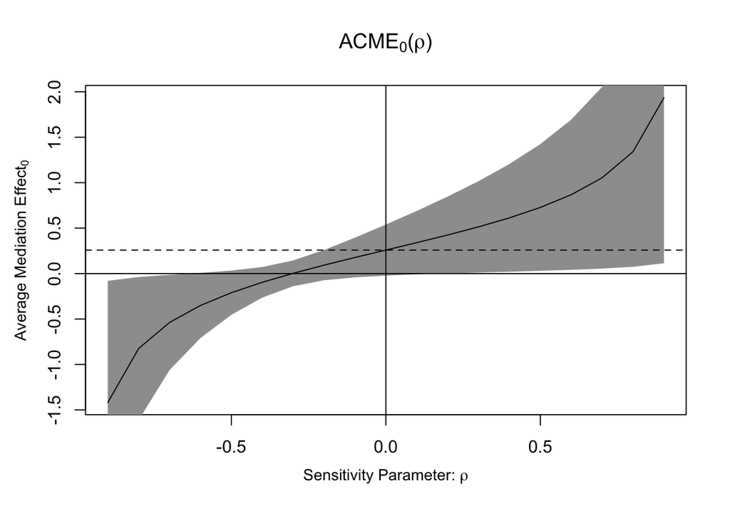

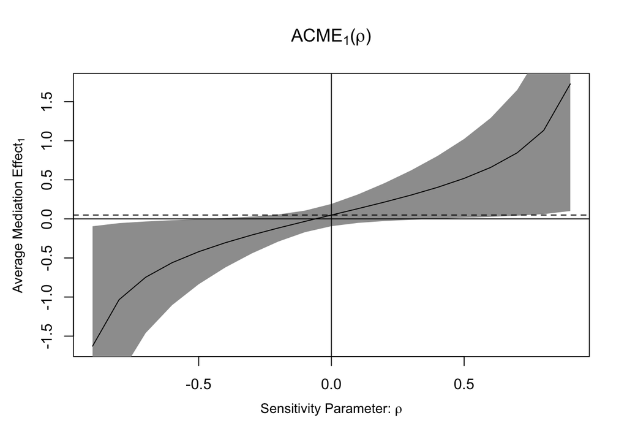

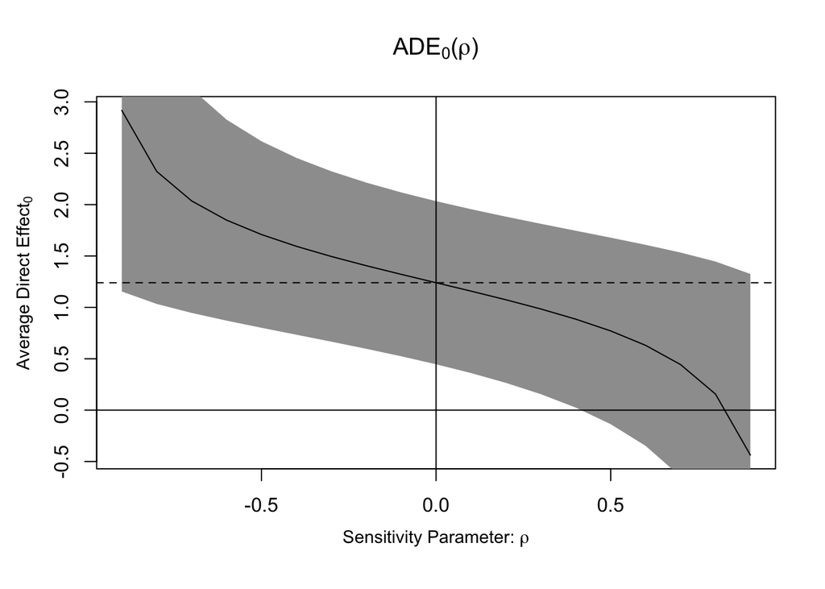

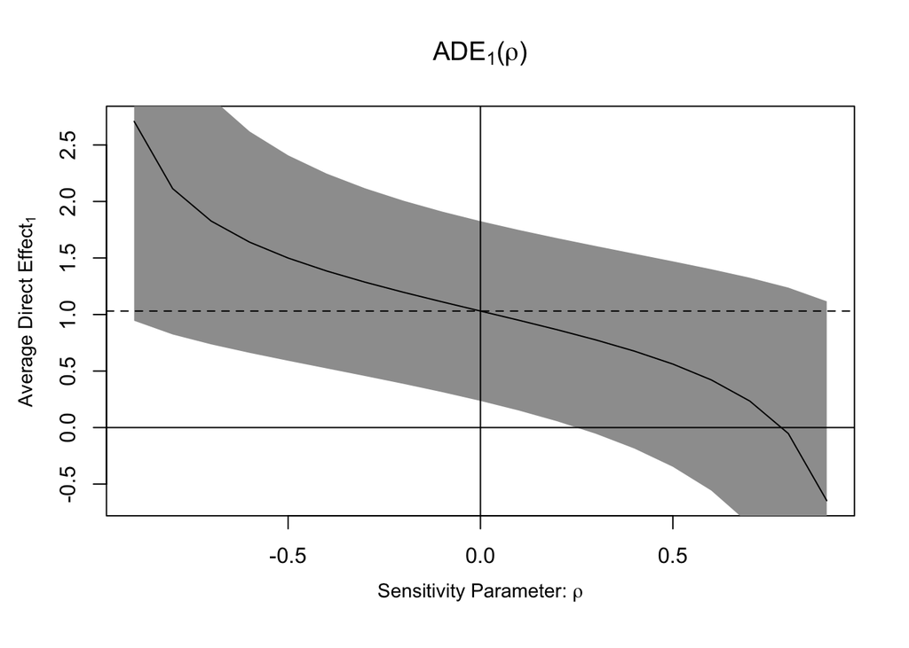

```r
# Sensitivity plots
plot(sens.out, sens.par = "rho")
```